# C02

Previous:Lecture 1 Introduction Next: Lecture 3 Datatype

Lecture 2 C Basics

#### CSCI218 Engineering Programming (by Kebin Xu)

1. **Example of C**
2. Standard input and output
   - printf() and scanf())
3. Bulding blocks of C
   - Variables and assignment
   - Identifiers and Naming Rule
   - Expressions
   - In-class exercise
   - Statement
   - for
   - function
4. **Writng Simple Program**
   - example of area of circle
   - **The Software Development Process**
   - 4.3 Exercise
- Objective
  - To apply variables in program development
  - To analyze assignment (semantics of LHS versus RHS) and apply its components in program development
  - To apply the software development process (problem definition, requirements specification, design, implementation, testing, and maintenance) in program development.

1. Example of C

ref [zybook 1.5(input&output)](https://learn.zybooks.com/zybook/COFCCSCI218XuFall2022/chapter/1/section/5)

```c
// <Filename>.c

/* This program was written by  <Programmer> on some date
  This program does something useful . . .

*/
#include <stdio.h>   // For accessing the standard library functions

int main()
{
    // Next line of code will print 'Hello, World !'
    // in the console(display)
     printf("Hello,      World! \n");



    printf("Hello, World!");

    //
    return 0;
}
```

```
Hello,      World!
Hello, World!
```

```c
#include <stdio.h>

int main()
{
    printf("Hello, World!     ");
    printf("welcome");

    //let 's do math
    int age; //declare vairable age
    age = 5;
    printf("\nafter 3 years, age is %d", age + 3);


    return 0;
}
```

```
Hello, World!     welcome
after 3 years, age is 8
```

```c
#include <stdio.h>

int main(void) {
  int wage;

  wage = 20;

  printf("Salary is ");
  printf("%d", wage * 40 * 52);
  printf("\n");

  return 0;
}
```

```
Salary is 41600
```

```c
#include <stdio.h>
int main()
{

    printf("my name is Dr. Xu");
    return 0;
}
```

```
my name is Dr. Xu
```

```c
#include <stdio.h>
int main()
{
    printf("Hello, World!");
    return 0;
}
```

```
Hello, World!
```

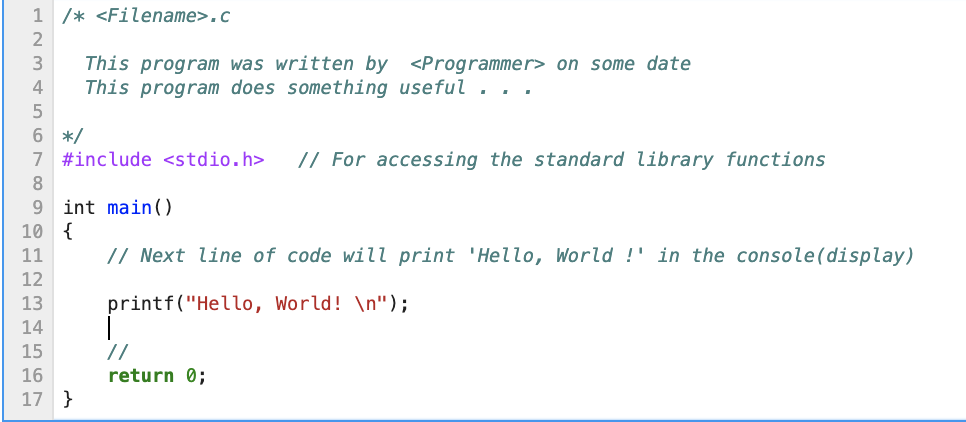

## 1.1 Explanation of Specific Lines

- **Line 1** The symbols /$*$ and $*$/ enclose a block comment, which may extend over any number of lines  
  EVERY well-written program should begin with a large block comment specifying the name of the file, the author of the program, when it was written, and a brief description of what the program does and why. In large projects the opening comment may include reference to external documents ( software requirements documentation ), and may include a revision history of who modified the program when and for what purposes.
- **Line 7** The #include statement informs the compiler of what libraries are needed.
  - `stdio.h` contains the definitions of standard input and output functions. It is very rare that a C program would not need this header file.
  - `//`, indicates a comment that extends to the end of the current line.
- **Line 9** says that we are starting a function named **main**, which is the starting point for all C programs.
  - The keyword **int** says that main returns an integer value as its `return` type. ( See line 16. )
  - The open brace indicates the beginning of a block of code, which must be matched by a closing brace ( on line 17. )
- **Line 13** "**printf**" is the standard library function for formatted printing
  - Any data can be output to standard output (stdout), the console display screen
  - A simple text string can be enclosed in double quotes, as shown
  - The `\n` indicates a new line character. Without this, all the printout would appear on a single line. Multiple `\n` characters yield blank lines.
  - Note the `semicolon` at the end of the line, which is how C knows that a statement has ended.
- **line 16** Every function must have a **return** statement, which causes the function to end and return control to whoever called it.
  - Because main was declared to have an integer return type in line 9, this function must return an integer.

### < Example >

[zyBook 1.5.1](https://learn.zybooks.com/zybook/COFCCSCI218XuFall2022/chapter/1/section/5)

## 1.2 How to compile and run a standard c program

All C language tools need to compile C code ( a file with extension .c) and assemble it. Further, they need to link this assembled code with other assembled modules and libraries in order to create a finished executable program.

1. Using **IDE**(integrated development environment), including a text editor. e. g. XCode, VScode + c compiler extension
2. Terminal/DOS Shell
   - gcc -o runme zb1-5-1.c
   - ./runme
3. Jupyter C kernel integrated in Jupyter notebook
4. Online compiler, for example: [Online C Compiler](https://www.onlinegdb.com/online_c_compiler) or [Tutorialspoint](https://www.tutorialspoint.com/compile_c_online.php)

## 1.3 Comments and whitespace

ref: ZB1.6, 1.10

A comment is text a programmer adds to code, to be read by humans to better understand the code but ignored by the compiler. Two common kinds of comments exist:

- A single-line comment starts with // and includes all the following text on that line. Single-line comments commonly appear after a statement on the same line.
- A multi-line comment starts with /$*$ and ends with $*$/, where all text between /$*$ and $*$/ is part of the comment. A multi-line comment is also known as a block comment.

Whitespace refers to blank spaces (space and tab characters) between items within a statement and blank lines between statements (called newlines). A compiler ignores most whitespace.

### good practice

make a program more readable

- Use blank lines to separate conceptually distinct statements.
- Indent lines the same amount.
- Align items to reduce visual clutter.
- Use a single space before and after any operators like =, +, *, or / to make* statements more readable.

back to top

2.Using Standard I/O (Input/Output)

[ZB 1.5](https://learn.zybooks.com/zybook/COFCCSCI218XuFall2022/chapter/1/section/5)

- Any data can be output to standard output (stdout), the console display screen
- C programming language treats all the devices as files

  Standard Files File Pointer Device

```
standard input     stdin          keyboard
standard output    stdout         screen
standard error     stderr         your screen
```

## 2.1 printf()

- The **printf()** function is used to print output from a program.
  - printf() allows a program to print `text` along with `formatted numbers and text`.
  - To use the printf() function, a program must include the stdio library using the statement **#include <stdio.h>**.
  - The first argument to the printf() function is a `format string`. The format string defines the format of the text that will be printed along with any number of **placeholders**, known as `format specifiers`, for printing numeric values and text stored in variables. It can specify %s, %d, %c, %f, etc., to print or read strings, integer, character or float respectively.
  - see [zyBook 2.20](https://learn.zybooks.com/zybook/COFCCSCI218XuFall2022/chapter/2/section/20), The detailed formating I/O
  - if we want to print a newline character, we use '\n'
- Example: [zyBook 1.5.1, zyBook 1.5.3](https://learn.zybooks.com/zybook/COFCCSCI218XuFall2022/chapter/1/section/5)

```c
// Example 1
#include <stdio.h>

int main(void) {

    int wage; // variable declaration
    wage = 20; // variable assignment

    char name[] = "Joe";

    printf("name: %s\n",name);
   // printf("%s\n", name);


    printf("wage is %d", wage);
    //printf("%d", wage);
    printf("\n");
    printf("%s's wage is %d",name, wage );


   return 0;
}
```

[output not shown]

## 2.2 scanf()

- The **scanf()** function can be used to read a user-entered value into a variable. (see **zyBook 1.5.3**: A program can get an input value from the keyboard.)
  - Similar to printf(), the first argument to scanf() is a format string that specifies the type of value to read. Thus, scanf("**%d**", **&**`age`); will read a **decimal integer** from the user input.
  - For each format specifier in the format string, scanf() must include a corresponding argument. The **&** before the variable name `age` indicates the **location** or **address** in memory of the variable, where scanf() will store the read value.
  - scanf() can also read a `string` into a character array, using **%s**. However, **no &** precedes the character array argument.
  - The example scanf("**%s**", `name`); illustrates will read a string (or character arrar) from the user input , and store the values to variable `name`. must not be used when reading a string.
  - A **common error** when trying to read a user-entered string (a character array) using scanf is to place an & before the string variable.
  - Similarly, a **common error** when using scanf to read a numeric or character data type is to forget the & before the variable name.

```
#include <stdio.h>

int main(void)
{
    char name[100]; int age;
    printf( "Enter your name :");
    scanf("%s", name);
    printf("Enter your age:");
    scanf("%d",&age);
    printf( "Your name is %s, and you are %d years old\n", name, age);
    printf("\nEnter your name and age:");
    scanf("%s %d", name, &age);
    printf("Name: %s, Age: %d",name, age);
    return 0;
}
```

```
Enter your name : James
Enter your age: 21
Your name is James, and you are 21 years old

Enter your name and age:Bond 38
Name: Bond, Age: 38
```

### note for scanf():

1. scanf() expect input in the same format as you provided %s and %d, which means you have to provide valid input like "string integer", if you provide "string string" or "integer integer" then it will be assumed as wrong input.
2. while reading a string, scanf() stops reading as soon as it encounters a space so "this is test" are three strings for scanf().

## Example of scanf()

see zyBook 1.5.2: Basic input

```c
//use onlinegdb.com
// Example 2
#include <stdio.h>

int main(void) {

    int wage; // variable declaration
    char name[100]; // variable declaration

    //ask for the input,
    //Good practice: prompt some hint
    printf("Please enter the wage:");
    scanf("%d", &wage);

    printf("wage is %d\n", wage);

    //ask for name
    printf("Enter the name:");
    scanf("%s", name);
    printf("%s's wage is %d",name, wage );

    //ask for more than one input
    printf("Enter the name and wage:");
    scanf("%s %d", name, &wage);
    printf("%s's wage is %d",name, wage );


   return 0;
}
```

back to top

3. Building blocks of C

back to top

## 3.1 Variables

- A variable is a name given to a location in memory where a value can be stored, and can be referred to in other places of the program.
- A variable has to be declared before it is used (declaration)(see [zyBook 1.5.1](https://learn.zybooks.com/zybook/COFCCSCI218XuFall2022/chapter/1/section/5) and [zyBook 2.2.1](https://learn.zybooks.com/zybook/COFCCSCI218XuFall2022/chapter/2/section/2))
- A variable is for a specific type ([data type](https://www.programiz.com/c-programming/c-data-types))
- Assign a value to a variable before using it for some other purpose, such as printing or having its value assigned to another variable. (assignment)
- Value can change during program execution (updating)
- Give variables valid names follow certain rules

### 3.1.1 Variable declaration

- General form for declaring a variable is: < data_type > < variable_name_list >;
- For example :
  - `char letter;`
  - `int i,j;`
  - `float x = 0.4;`

```c
// Example 3
#include <stdio.h>
int main()
{
    int age;
    char letter = 'a';
    float x = 0.4;
    age = 0b10100; //or 0b10100 in binary, 0x14 in hexadecimal, 024 in octal
    //age = 3.5; //invalid
    printf("age is %d!\n",age);

    return 0;

}
```

```
age is 20!
```

```c
#include <stdio.h>

int main(void) {
   int x;
   int y;
   int z;
   x = 5;
   y = x + 5;
    printf("x = %d\n", x);
   printf("x = %d, y = %d\n", x, y);
   x =  20;
   printf("x = %d, y = %d\n", x, y);
   y = z;
   printf("x = %d, y = %d, z = %d\n", x, y, z);



   return 0;
}
```

```
x = 5
x = 5, y = 10
x = 20, y = 10
x = 20, y = 174420064, z = 174420064
```

### 3.2.2 Variable Assignment

- < variable > = < expr >
- When assigning values, we put the **variable** to be assigned to on the left hand side **(LHS)**, while the **value** to plug in on the **RHS**. LHS and RHS are connected by an equal sign (`=`), meaning assignment.

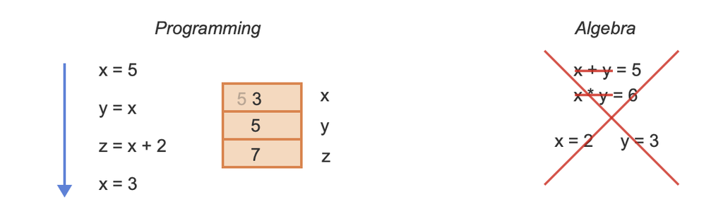

- Assign a value to a variable before using it for some other purpose, such as printing or having its value assigned to another variable. (assignment)

### 3.2.3 Updating variable value:

- A variable takes different values at different times.
- Can hold only one value
  - Whenever a new value is placed into a variable, the new value replaces the previous value.

```c
// Example 4
#include <stdio.h>

int main(void) {

    /* declare 3 integers
    int x;
    int y;
    int z;
    */
    int x, y, z; //declare 3 integers

    /* variable assignment */
    x = 5; // assignment
    //assign y using another variable (must hold value already)
    y = x;
    printf("x = %d y = %d\n", x, y);

    /*can you do the following ?
    y = z; // z is not initiated by the user, so will have random integer
    printf("x = %d y = %d\n", x, y);
    */
    z = x + 2; //x+2 is expression (evaluaed as integer 7)
    printf("x = %d y = %d z = %d\n", x, y,z);

    //can you do this?
    //x + y = 10; //invalid

    /*updating variable's value */
    x = 3;
    printf("updating x: x = %d y = %d z = %d\n", x, y,z);

    //updating variable's value
    y = y * 5;
    z = z + 5; // z += 5;
    printf("updating y: x = %d y = %d z = %d\n", x, y,z);
    return 0;
}
```

```
x = 5 y = 5
x = 5 y = 5 z = 7
updating x: x = 3 y = 5 z = 7
updating y: x = 3 y = 25 z = 12
```

back to top

## 3.3 Identifiers and Naming Rule

see [zyBook2.3](https://learn.zybooks.com/zybook/COFCCSCI218XuFall2022/chapter/2/section/3)

A C **identifier** is a name used to identify a `variable`, `function`, or any other `user-defined item`.

#### Naming convention

There are two commonly used **style** in programming for compound words:

1. **camelCase** or **lowerCamelCase**
2. **snake_case** or **lower_case_with_underscore**

#### C Naming policy

1. All variables should be `meaningful`, long enough to give me a clue as to what they do in a program, but short enough as representative
2. Every variable must begin with a `alphabet` or `underscore` (_), followed by any sequence of alphabet, digits, or underscores!
3. variables are case sensitive.
4. C names use `camelCase`
5. cannot be keyword or pre-written functions (e.g. delay() in Arduino C), see [Arduino functions](https://www.arduino.cc/reference/en/)

#### Keywords

Keywords(also called ‘Reserved words’) are the words that have specific and predefined meaning in the C programming language. All keywords are lowercased.

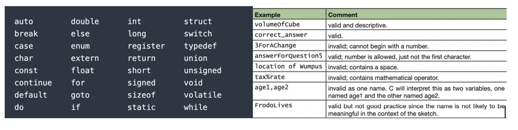

Back to top

## 3.4 Expressions

see [zyBook2.4](https://learn.zybooks.com/zybook/COFCCSCI218XuFall2022/chapter/2/section/4)

An **expression** is created by combining **operands** and **operators**. For example

- a + b
- b * 5
- 15 > num2
- operands: can be
  - a **variable**(e.g. a, b) ,
  - a **literal** (constant value, e.g. 5, 'A', "James"). A notation for representing a **fixed** value in source code. Its value cannot be changed as a program runs. Literals are often used to initialize variables. For example, the text was contained inside double quotation marks.
  - a **constant** (e.g. PI)
- operators: arithmatic operators(+, -, *, /, %, ++ ), relational operators (>, <, <=, ==), or logical operators (&&, ||, !), etc.
  - unary operators(e.g. `!` , `++`) and binary operators (+, *, <=, = )
  - more details about operators and **precedence** see [zybook Table2.4.2](https://learn.zybooks.com/zybook/COFCCSCI218XuFall2022/chapter/2/section/4): Precedence rules for arithmetic operators.[C operators](https://www.tutorialspoint.com/cprogramming/c_operators.htm)
- for example: x = a + b $*$ 5; here, x is assigned 35 if a holds 5 and b holds 6 , not 55 because operator *has a higher precedence than +, so it first gets multiplied with 6*5 and then adds into 5.

### 3.4.1 Arithmetic Operators

Following table shows all the arithmetic operators supported by C language. Assume variable A holds 10 and variable B holds 20, then:

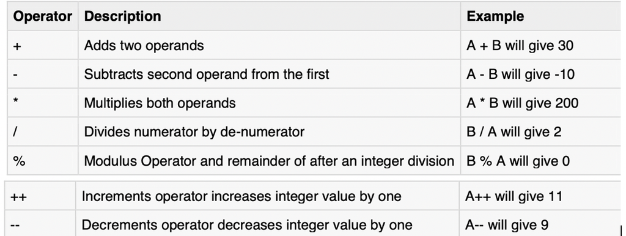

**Notes**: the `-` operator is also for negation, as in -x + y, or x + -y.

```c
#include <stdio.h>
int main()
{
    int a = 25;
    int b = 10; int c ;
    printf("a = %d, b = %d\n", a, b);



    c = a + b;
    printf("c = a + b - Value of c is %d\n", c );
    c = a - b;
    printf("c = a - b - Value of c is %d\n", c );
    c = a * b;
    printf("c = a * b - Value of c is %d\n", c );
    c = a / b;
    printf("c = a / b - Value of c is %d\n", c );

    c = a % b;
    printf("c = a %% b - Value of c is %d\n", c );

    a++;
    b--;
    printf("after a++, b--: a = %d, b = %d\n", a, b);
    ++a;
    --b;
    printf("after ++a, --b: a = %d, b = %d\n", a, b);

    //FYI:
    c = a++; // c = a; then a++
    printf("c = a++ : Value of c is %d, a is %d \n", c,a );
    c = a--;
    printf("c = a-- : Value of c is %d, a is %d \n", c,a );

    c = ++a; //  a++, then assign to c
    printf("c = ++a : Value of c is %d, a is %d \n", c, a );
    c = --a;
    printf("c = --a : Value of c is %d, a is %d \n", c,a );


    return 0;
}
```

```
a = 25, b = 10
c = a + b - Value of c is 35
c = a - b - Value of c is 15
c = a * b - Value of c is 250
c = a / b - Value of c is 2
c = a % b - Value of c is 5
after a++, b--: a = 26, b = 9
after ++a, --b: a = 27, b = 8
c = a++ : Value of c is 27, a is 28
c = a-- : Value of c is 28, a is 27
c = ++a : Value of c is 28, a is 28
c = --a : Value of c is 27, a is 27
```

### Precedence rules for arithmetic operators.

see [zbTable2.4.2](https://learn.zybooks.com/zybook/COFCCSCI218XuFall2023/chapter/2/section/4)

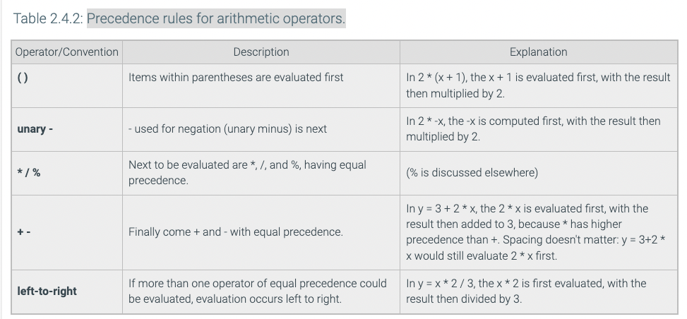

### 3.4.2 Assignment operator

see [zyBook2.5](https://learn.zybooks.com/zybook/COFCCSCI218XuFall2022/chapter/2/section/5)

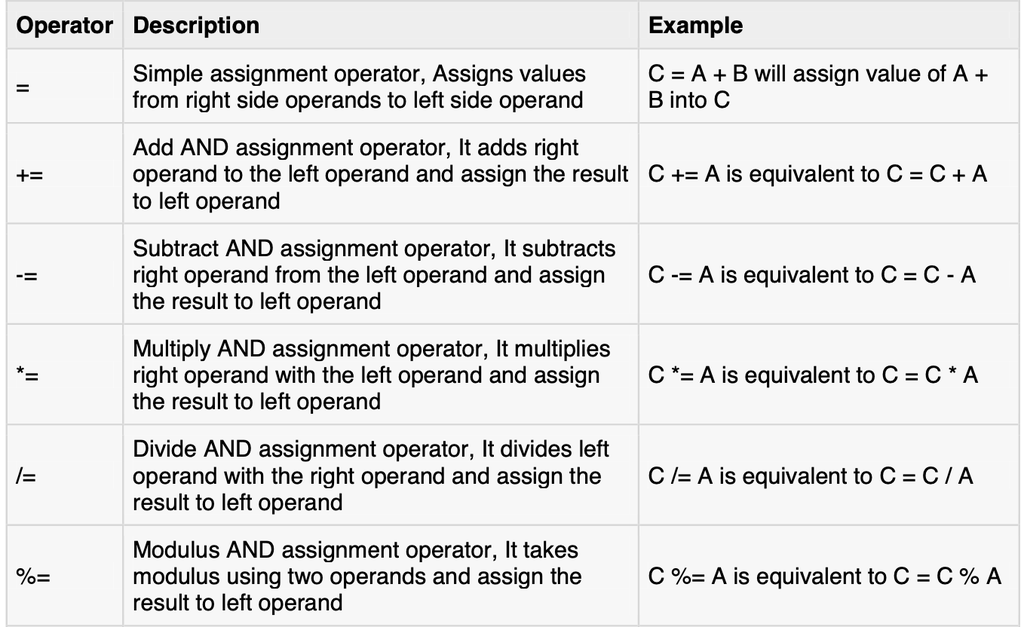

above assignment operators except `=` are called **compound operators**

```c
//Example 5
#include <stdio.h>

int main(void) {

    char nameOfSchool[] = "CofC"; //variable declaration and assignment
    int numOfStudent = 10000; //variable declaration and assignment

    /*increase number of student by 1000 */

    //numOfStudent = numOfStudent + 1000;
    //using compound operators
    numOfStudent +=   1000; // numOfStudent = numOfStudent + 1000;

    printf("After one year, the numer of students in %s is %d\n", nameOfSchool, numOfStudent);

    /*declare integer x, y, z */
    int x , y, z ; //multiple variables declaration in one statement
    x = 1, y = 1, z = 1; //variable initialization/assignment in one statement
    x += 6; // x = x + 6;
    y /= 5; // y = y / 5;
    z *= 5; // z = z * 5;

    printf("x = %d, y = %d, z = %d \n", x, y, z);

  return 0;
}
```

[output not shown]

back to top

### inclass exercise

Valid/Invalid expression?

- x + 5y
- x + -y

Is the following an error? Suppose an int's maximum value is 2,147,483,647.

- int numYears = 1,999,999,999;

back to top

### 3.4 Constant

see [zyBook2.9](https://learn.zybooks.com/zybook/COFCCSCI218XuFall2022/chapter/2/section/5)

Constants are like a variable, except that their value never changes during execution once defined. Using keyword `const` to define

```
const <datatype> <constant name> = <fixed value>
```

For example

```c
// Example constant
# include <stdio.h>
int main() {
    const int LED_BUILTIN = 13;
    const float PI = 3.1415926;
    printf("LED_BUILTIN = %d, PI = %f", LED_BUILTIN, PI);
}
```

```
LED_BUILTIN = 13, PI = 3.141593
```

Another way to define a constant is using

```
#define LED_BUILTIN 13
```

- #define is a preprocessor directive.
- Things defined by #define are replaced by the preprocessor before compilation begins.

back to top

## 3.6 Statements

C is an [imperative language](https://en.wikipedia.org/wiki/Imperative_programming) based on. That is, programs in C consists of lines composed of **statements**. A statement can be:

### 3.6.1. Simple Statement

```
 - an assignment(simple & compound assignment)
 - a function call
```

Each line of a C code ending with `;`

```c
/* simple statement example  example6.c
By Dr. Xu
This program is for explaining the building blocks of C
*/

# include <stdio.h>    //For accessing the standard library functions

int main() {
    /*  literals: "James", 3.14, 5, 6, PI, '!'
        Variables: a, b, name, c, punc
        Constant: PI
        Expressions: a + 6, a + b * 3,
        function: printf
        datatype: char, int, float
    */

    int a, b;    //variable declaration ;
    a = 5;       // variable assignment
    b = a + 6;   // variable assignment
    int c = a + b * 3;     //variable declaration and initialization
    const float PI = 3.14; // define a constant with float datatype
    printf("a = %d, b = %d\na + b * 3 = %d, PI = %f\n", a, b, a + b * 3, PI ); //function call
    char name[] = "James";  // double quotes for string
    char punc = '!';        // single quotes for character

    printf("Good bye, %s %c \n", name, punc);
    return 0;
}
```

```
a = 5, b = 11
a + b * 3 = 38, PI = 3.140000
Good bye, James !
```

### 3.6.2. Compound statements: (will be covered later)

Compound staements are enclosed in `{}` pair, usually in conditional branch, loop and function defination, detail will be in covered in [zyBook3branch](https://learn.zybooks.com/zybook/COFCCSCI218XuFall2022/chapter/3/section/1) , [zyBook4loop](https://learn.zybooks.com/zybook/COFCCSCI218XuFall2022/chapter/4/section/1) and [zyBook6Function](https://learn.zybooks.com/zybook/COFCCSCI218XuFall2022/chapter/6/section/1)

#### Compound statement examples

```c
//C branches
#include <stdio.h>
int main() {
    float temperature = 77;
    if(temperature < 32) {
        printf("brrr");
        printf("   Too cold");
    } else if(temperature < 100) {
        printf("hooray");
    } else {
        printf("ouch!");
    }
    return 0;
}
```

```
hooray
```

```c
#include <stdio.h>
int main() {
    printf("Welcome!\n");
    printf("Welcome!\n");
    printf("Welcome!\n");
    printf("Welcome!\n");
    printf("Welcome!\n");
    printf("Welcome!\n");
    printf("Welcome!\n");
    printf("Welcome!\n");
    printf("Welcome!\n");
    printf("Welcome!\n");
    return 0;
}
```

```
Welcome!
Welcome!
Welcome!
Welcome!
Welcome!
Welcome!
Welcome!
Welcome!
Welcome!
Welcome!
```

```c
//Using for loop
#include <stdio.h>
int main()
{
    int i;
    // loop index i increment by 1 can also be written as i++, or i += 1
    for (i = 0; i < 10; i += 1){
        printf("Welcome! \n");
        //printf("The index i is \n", i);
    }
    return 0;
}
```

```
Welcome!
Welcome!
Welcome!
Welcome!
Welcome!
Welcome!
Welcome!
Welcome!
Welcome!
Welcome!
```

### for loop (will be covered later)

**for** loop:

- A type of loop in which the number of times the statements in a loop run is numerically defined.
- It used to execute a set of programming statements multiple times

[figure not shown]

- The for loop statement itself has three parts. Each places a role in setting up and running a logical test that determines how many times the statements are executed.
  - initial condition,
  - the test,
  - the increment.

Eventually the programming statements in increment will create a situation where the test no lon- ger evaluates to true. When this happens, the programming statements within the curly braces are no longer executed, and the program will move to what comes after the for loop.

back to top

### Function block

- Function is a group of statements that together perform a task.
- Every C program has at least one function, which is main(), and all the most trivial programs can define additional functions.
- You can divide up your code into separate functions.
  - How you divide up your code among different functions is up to you, but logically the division usually is so each function performs a specific task.
- A **function declaration** tells the compiler about a function's name, return type, and parameters.
- A **function definition** provides the actual body of the function.
- A function is known with various names like a `method` or a `sub-routine` or a `procedure`, etc.
- The detailed of function will be covered in chapter 6

[figure not shown]

- Case1: if your function defination is written after the caller(where you call the function), you have to put the function declaration before the caller, usually we put all function declarations at the beginning of the code,
  - or make another hearder file funcs.h, then add #include <funcs.h> in the beginning of the code
- Case2: if your function defination is written before the caller, you can omit the function declaration statement

```c
// Case1
#include <stdio.h>;
void greet();//function declaration
int main(){
    greet(); //call function greet() in the caller main()
    return 0;

}
void greet(){
    printf("Welcome to my CSCI218!\n");
    printf("Today is a good day!\n");
}
```

```
Welcome to my CSCI218!
Today is a good day!
```

```c
// Case2
#include <stdio.h>

void greet(){
    printf("Welcome to my CSCI218!\n");
    printf("Today is a good day!\n");
}
int main(){
    greet(); //call function greet() in the caller main()
    printf("\ncall greet() again!\n\n");
    greet();
    return 0;

}
```

```
Welcome to my CSCI218!
Today is a good day!

call greet() again!

Welcome to my CSCI218!
Today is a good day!
```

```c
// function call in a loop
#include <stdio.h>

void greet(){
    printf("Welcome to my CSCI218!\n");
}
int main(){

    for(int i = 0;i < 5; i++){
        greet(); //call function greet() in the caller main()
    }
    return 0;
}
```

```
Welcome to my CSCI218!
Welcome to my CSCI218!
Welcome to my CSCI218!
Welcome to my CSCI218!
Welcome to my CSCI218!
```

back to top

# 4. Write simple program

## 4.1. The Software Development Process

The process of creating a program is often broken down into stages according to the information that is produced in each phase

- also see the example from textbook chapter 2 pp.28 for Arduino program

**Six Steps** of the software development process.

1. Analyze the problem
2. Determine the specification (inputs, outputs and how are they related)(**IPO**)
3. Create a design (algorithm/pseudocode)
4. Implement the design
5. Test/debug the program
6. Maintain the program

### 4.2 Example:

- calculate the area of a circle

### 4.2.1 Analize the problem

Figure out exactly the problem to be solved. Try to understand it as much as possible.

**Ans**:

- `circleArea`: calcuate the area of a circle given the radius

### 4.2.2 Determine specifications

Describe exactly what your program will do.

- Don’t worry about how the program will work, but **what** it will do.
- Includes describing the **inputs, outputs**, and **how they relate** to one another.

`circleArea`:**Ans:**

- Input: radius
- Output: area
- Process: Output = input x input x PI

### 4.2.3 Create a Design

- Formulate the overall structure of the program. This is where the how of the program gets worked out.
- Develop your own **algorithm** that meets the specifications. (A step-by-step set of instructions for accomplishing some task is called a algorithm)
- the algorithm is writen in pseudocode, which is just precise English that describes what a program does.
- the simple algorithm can follows a standard pattern: `Input, Process, Output` (**IPO**).

circleArea **Pseudocode:**

- `Input` : receive the input from user and store the value to a variable `radius`
- `Process` calculate area by using the formula: $A = \pi r^2)$
- `Output` display `area` on the screen

### 4.2.4 Implement the Design

- Translate the design into a computer language. (C)
  - What are the variables to use, and what is the data type for each variable
  - plug in the pseudocode as the comments

```c
//circleArea
#include <stdio.h>

int main(){
    // display the purpose of the program

    // define the variable: radius and area, both with datatype float

    // input: receive radius from the user (keyboard)


    // process: Calculate area by using the formula of a circle


    // output: display the `area` on the screen


    return 0;
}
```

```c
#include <stdio.h>

int main(){
    // display the purpose of the program
    printf("The program is to calculate the area of a circle with radius given by the user.\n") ;

    // define the variable: radius and area, both with datatype float
    float radius, area;

    // input: receive radius from the user (keyboard)
    printf("Enter the radius of a circle:");
    scanf("%f", &radius);

    // process: Calculate area by using the formula of a circle
    area = 3.1415926 * radius * radius;

    // output: display the `area` on the screen
    printf("The area of a circle with radius %f is %f.\n", radius,area);

    return 0;
}
```

### 4.2.5 Test/Debug the program

- Try out your program to see if it worked. If there are any errors (bugs), they need to be located and fixed. This process is called debugging.
- Your goal is to find errors, so try everything that might “break” your program!

### 4.2.6 Maintain the program

- improve
- add file name, author name, purpose of the problem statement, edition number, etc.

```c
/* circleArea.c
by Dr. Xu
The program is to calculate the area of a circle with radius given by the user
*/

#include <stdio.h>
#include <math.h>
int main(){
    // display the purpose of the program
    printf("The program is to calculate the area of a circle with radius given by the user.\n") ;

    // define the variable: radius and area, both with datatype float
    float radius, area;
    const float PI = 3.1415926;
    // input: receive radius from the user (keyboard)
    printf("Enter the radius of a circle:");
    scanf("%f", &radius);

    // process: Calculate area by using the formula of a circle
    area = PI * pow(radius, 2);

    // output: display the `area` on the screen
    printf("The area of a circle with radius %f is %f.\n", radius,area);

    return 0;
}
```

back to top

### 4.3 Exercise:

- Temperature Conversion (Celsius to Fahrenheit)
1. Analyze the problem
   - `C2F`: the temperature is given in Celsius, user wants it expressed in degrees Fahrenheit
2. Determine the specification (inputs, outputs and how are they related)(IPO)
   - Input – temperature in Celsius
   - Output – temperature in Fahrenheit
   - Process: Output = 9/5(input) + 32
3. Create a design (algorithm/pseudocode) **IPO**
   - `Input`: receive the input from the user (keyboard) the temperature in degrees Celsius (call it `celsius`)
   - `Process`: Calculate fahrenheit by using the formula: $F = \frac{9}{5}C + 32$
   - `Output`: display the `fahrenheit` on the screen
4. Implement the design

Back to top